# tidyverse

Г. Мороз

### 1. Введение

[*tidyverse*](https://www.tidyverse.org) — это набор пакетов:

- *dplyr*, для преобразованиия данных
- *ggplot2*, для визуализации
- *tidyr*, для формата tidy data
- *readr*, для чтения файлов в R
- *purrr*, для функционального программирования
- *tibble*, для работы с тибблами, современный вариант датафрейма

Полезно также знать:

- *readxl*, для чтения .xls и .xlsx
- *jsonlite*, для работы с JSON
- *rvest*, для веб-скреппинга
- *lubridate*, для работы с временем
- *tidytext*, для работы с текстами и корпусами
- *broom*, для перевода в tidy формат статистические модели

```r
library(tidyverse)
```

### 2. tible

```r
head(iris)
as_tibble(iris)
data_frame(id = 1:12,
           letters = month.name)
```

[output not shown]

### 3. Чтение файлов: readr, readxl

```r
library(readr)
df <- read_csv("https://raw.githubusercontent.com/agricolamz/2019.07.29_ANDAN_tidyverse/master/data/anscombe.s.quartet.csv")
head(df)
```

```
## # A tibble: 6 x 3
##       x     y dataset
##   <dbl> <dbl>   <dbl>
## 1    10  8.04       1
## 2     8  6.95       1
## 3    13  7.58       1
## 4     9  8.81       1
## 5    11  8.33       1
## 6    14  9.96       1
```

```r
df <- read_tsv("https://raw.githubusercontent.com/agricolamz/2019.07.29_ANDAN_tidyverse/master/data/datasaurus.tsv")
head(df)
```

```
## # A tibble: 6 x 3
##   dataset     x     y
##   <chr>   <dbl> <dbl>
## 1 dino     55.4  97.2
## 2 dino     51.5  96.0
## 3 dino     46.2  94.5
## 4 dino     42.8  91.4
## 5 dino     40.8  88.3
## 6 dino     38.7  84.9
```

```r
df <- read_delim("https://raw.githubusercontent.com/agricolamz/2019.07.29_ANDAN_tidyverse/master/data/datasaurus.tsv", delim = "\t")
head(df)
```

```
## # A tibble: 6 x 3
##   dataset     x     y
##   <chr>   <dbl> <dbl>
## 1 dino     55.4  97.2
## 2 dino     51.5  96.0
## 3 dino     46.2  94.5
## 4 dino     42.8  91.4
## 5 dino     40.8  88.3
## 6 dino     38.7  84.9
```

```r
library(readxl)
xlsx_example <- readxl_example("datasets.xlsx")
df <- read_excel(xlsx_example)
head(df)
```

```
## # A tibble: 6 x 5
##   Sepal.Length Sepal.Width Petal.Length Petal.Width Species
##          <dbl>       <dbl>        <dbl>       <dbl> <chr>
## 1          5.1         3.5          1.4         0.2 setosa
## 2          4.9         3            1.4         0.2 setosa
## 3          4.7         3.2          1.3         0.2 setosa
## 4          4.6         3.1          1.5         0.2 setosa
## 5          5           3.6          1.4         0.2 setosa
## 6          5.4         3.9          1.7         0.4 setosa
```

```r
excel_sheets(xlsx_example)
```

```
## [1] "iris"     "mtcars"   "chickwts" "quakes"
```

```r
df <- read_excel(xlsx_example, sheet = "mtcars")
head(df)
```

```
## # A tibble: 6 x 11
##     mpg   cyl  disp    hp  drat    wt  qsec    vs    am  gear  carb
##   <dbl> <dbl> <dbl> <dbl> <dbl> <dbl> <dbl> <dbl> <dbl> <dbl> <dbl>
## 1  21       6   160   110  3.9   2.62  16.5     0     1     4     4
## 2  21       6   160   110  3.9   2.88  17.0     0     1     4     4
## 3  22.8     4   108    93  3.85  2.32  18.6     1     1     4     1
## 4  21.4     6   258   110  3.08  3.22  19.4     1     0     3     1
## 5  18.7     8   360   175  3.15  3.44  17.0     0     0     3     2
## 6  18.1     6   225   105  2.76  3.46  20.2     1     0     3     1
```

```r
rm(df)
```

### 4. `dplyr`

```r
homo <- read_csv("https://raw.githubusercontent.com/agricolamz/r_on_line_course_data/master/Chi.kuk.2007.csv")
homo
```

```
## # A tibble: 14 x 10
##    speaker s.duration.ms vowel.duration.… average.f0.Hz f0.range.Hz
##    <chr>           <dbl>            <dbl>         <dbl>       <dbl>
##  1 A                61.4            113.           120.        52.5
##  2 B                63.9            126.           100.       114
##  3 C                55.1            127.           115.       103.
##  4 D                78.1            119.           127.        58.8
##  5 E                64.7             93.7          131.        37.4
##  6 F                67              128.           151.        42
##  7 G                65.4            148.           129.       118.
##  8 H                62.5            120.           105.        55.7
##  9 I                60.4            140.           110.        96.4
## 10 J                59.6            121.           124.       112.
## 11 K                62.9            137.           119.        87.6
## 12 L                53.3            112.           146.        57.8
## 13 M                45.1            134.           155.       100.
## 14 N                57.7            118.           121.        37.4
## # … with 5 more variables: perceived.as.homo <dbl>,
## #   perceived.as.hetero <dbl>, perceived.as.homo.percent <dbl>,
## #   orientation <chr>, age <dbl>
```

The majority of examples in that presentation are based on [Hau 2007](http://goo.gl/MKfSc6). Experiment consisted of a perception and judgment test aimed at measuring the correlation between acoustic cues and perceived sexual orientation. Naïve Cantonese speakers were asked to listen to the Cantonese speech samples collected in Experiment and judge whether the speakers were gay or heterosexual. There are 14 speakers and following parameters:

- [s] duration (*s.duration.ms*)
- vowel duration (*vowel.duration.ms*)
- fundamental frequencies mean (F0) (*average.f0.Hz*)
- fundamental frequencies range (*f0.range.Hz*)
- percentage of homosexual impression (*perceived.as.homo*)
- percentage of heterosexal impression (*perceived.as.hetero*)
- speakers orientation (*orientation*)
- speakers age (*age*)

#### 4.1 `dplyr::filter()`

```r
homo %>%
  filter(age > 28, s.duration.ms < 60)
```

```
## # A tibble: 3 x 10
##   speaker s.duration.ms vowel.duration.… average.f0.Hz f0.range.Hz
##   <chr>           <dbl>            <dbl>         <dbl>       <dbl>
## 1 C                55.1             127.          115.       103.
## 2 J                59.6             121.          124.       112.
## 3 N                57.7             118.          121.        37.4
## # … with 5 more variables: perceived.as.homo <dbl>,
## #   perceived.as.hetero <dbl>, perceived.as.homo.percent <dbl>,
## #   orientation <chr>, age <dbl>
```

`%>%` — конвеер (pipe) отправляет результат работы одной функции в другую.

```r
sort(sqrt(abs(sin(1:22))), decreasing = TRUE)
```

```
##  [1] 0.9999951 0.9952926 0.9946649 0.9805088 0.9792468 0.9554817 0.9535709
##  [8] 0.9173173 0.9146888 0.8699440 0.8665952 0.8105471 0.8064043 0.7375779
## [15] 0.7325114 0.6482029 0.6419646 0.5365662 0.5285977 0.3871398 0.3756594
## [22] 0.0940814
```

```r
1:22 %>%
  sin() %>%
  abs() %>%
  sqrt() %>%
  sort(., decreasing = TRUE) # зачем здесь точка?
```

```
##  [1] 0.9999951 0.9952926 0.9946649 0.9805088 0.9792468 0.9554817 0.9535709
##  [8] 0.9173173 0.9146888 0.8699440 0.8665952 0.8105471 0.8064043 0.7375779
## [15] 0.7325114 0.6482029 0.6419646 0.5365662 0.5285977 0.3871398 0.3756594
## [22] 0.0940814
```

Конвееры в *tidyverse* пришли из пакета *magrittr*. Иногда они работают не корректно с функциями не из *tidyverse*.

#### 4.2 `dplyr::slice()`

```r
homo %>%
  slice(3:7)
```

```
## # A tibble: 5 x 10
##   speaker s.duration.ms vowel.duration.… average.f0.Hz f0.range.Hz
##   <chr>           <dbl>            <dbl>         <dbl>       <dbl>
## 1 C                55.1            127.           115.       103.
## 2 D                78.1            119.           127.        58.8
## 3 E                64.7             93.7          131.        37.4
## 4 F                67              128.           151.        42
## 5 G                65.4            148.           129.       118.
## # … with 5 more variables: perceived.as.homo <dbl>,
## #   perceived.as.hetero <dbl>, perceived.as.homo.percent <dbl>,
## #   orientation <chr>, age <dbl>
```

#### 4.3 `dplyr::select()`

```r
homo %>%
  select(8:10)
```

```
## # A tibble: 14 x 3
##    perceived.as.homo.percent orientation   age
##                        <dbl> <chr>       <dbl>
##  1                      0.28 hetero         30
##  2                      0.8  hetero         19
##  3                      0.36 homo           29
##  4                      0.6  homo           36
##  5                      0.4  homo           27
##  6                      0.68 homo           33
##  7                      0.8  hetero         28
##  8                      0.84 hetero         22
##  9                      0.8  homo           22
## 10                      0.32 homo           40
## 11                      0.84 homo           30
## 12                      0.32 hetero         25
## 13                      0.36 hetero         20
## 14                      0.16 hetero         29
```

```r
homo %>%
  select(speaker:average.f0.Hz)
```

```
## # A tibble: 14 x 4
##    speaker s.duration.ms vowel.duration.ms average.f0.Hz
##    <chr>           <dbl>             <dbl>         <dbl>
##  1 A                61.4             113.           120.
##  2 B                63.9             126.           100.
##  3 C                55.1             127.           115.
##  4 D                78.1             119.           127.
##  5 E                64.7              93.7          131.
##  6 F                67               128.           151.
##  7 G                65.4             148.           129.
##  8 H                62.5             120.           105.
##  9 I                60.4             140.           110.
## 10 J                59.6             121.           124.
## 11 K                62.9             137.           119.
## 12 L                53.3             112.           146.
## 13 M                45.1             134.           155.
## 14 N                57.7             118.           121.
```

```r
homo %>%
  select(-speaker)
```

```
## # A tibble: 14 x 9
##    s.duration.ms vowel.duration.… average.f0.Hz f0.range.Hz
##            <dbl>            <dbl>         <dbl>       <dbl>
##  1          61.4            113.           120.        52.5
##  2          63.9            126.           100.       114
##  3          55.1            127.           115.       103.
##  4          78.1            119.           127.        58.8
##  5          64.7             93.7          131.        37.4
##  6          67              128.           151.        42
##  7          65.4            148.           129.       118.
##  8          62.5            120.           105.        55.7
##  9          60.4            140.           110.        96.4
## 10          59.6            121.           124.       112.
## 11          62.9            137.           119.        87.6
## 12          53.3            112.           146.        57.8
## 13          45.1            134.           155.       100.
## 14          57.7            118.           121.        37.4
## # … with 5 more variables: perceived.as.homo <dbl>,
## #   perceived.as.hetero <dbl>, perceived.as.homo.percent <dbl>,
## #   orientation <chr>, age <dbl>
```

```r
homo %>%
  select(-c(speaker, perceived.as.hetero, perceived.as.homo, perceived.as.homo.percent))
```

```
## # A tibble: 14 x 6
##    s.duration.ms vowel.duration.… average.f0.Hz f0.range.Hz orientation
##            <dbl>            <dbl>         <dbl>       <dbl> <chr>
##  1          61.4            113.           120.        52.5 hetero
##  2          63.9            126.           100.       114   hetero
##  3          55.1            127.           115.       103.  homo
##  4          78.1            119.           127.        58.8 homo
##  5          64.7             93.7          131.        37.4 homo
##  6          67              128.           151.        42   homo
##  7          65.4            148.           129.       118.  hetero
##  8          62.5            120.           105.        55.7 hetero
##  9          60.4            140.           110.        96.4 homo
## 10          59.6            121.           124.       112.  homo
## 11          62.9            137.           119.        87.6 homo
## 12          53.3            112.           146.        57.8 hetero
## 13          45.1            134.           155.       100.  hetero
## 14          57.7            118.           121.        37.4 hetero
## # … with 1 more variable: age <dbl>
```

```r
homo %>%
  select(speaker, age, s.duration.ms)
```

```
## # A tibble: 14 x 3
##    speaker   age s.duration.ms
##    <chr>   <dbl>         <dbl>
##  1 A          30          61.4
##  2 B          19          63.9
##  3 C          29          55.1
##  4 D          36          78.1
##  5 E          27          64.7
##  6 F          33          67
##  7 G          28          65.4
##  8 H          22          62.5
##  9 I          22          60.4
## 10 J          40          59.6
## 11 K          30          62.9
## 12 L          25          53.3
## 13 M          20          45.1
## 14 N          29          57.7
```

#### 4.4 `dplyr::arrange()`

```r
homo %>%
  arrange(orientation, desc(age))
```

```
## # A tibble: 14 x 10
##    speaker s.duration.ms vowel.duration.… average.f0.Hz f0.range.Hz
##    <chr>           <dbl>            <dbl>         <dbl>       <dbl>
##  1 A                61.4            113.           120.        52.5
##  2 N                57.7            118.           121.        37.4
##  3 G                65.4            148.           129.       118.
##  4 L                53.3            112.           146.        57.8
##  5 H                62.5            120.           105.        55.7
##  6 M                45.1            134.           155.       100.
##  7 B                63.9            126.           100.       114
##  8 J                59.6            121.           124.       112.
##  9 D                78.1            119.           127.        58.8
## 10 F                67              128.           151.        42
## 11 K                62.9            137.           119.        87.6
## 12 C                55.1            127.           115.       103.
## 13 E                64.7             93.7          131.        37.4
## 14 I                60.4            140.           110.        96.4
## # … with 5 more variables: perceived.as.homo <dbl>,
## #   perceived.as.hetero <dbl>, perceived.as.homo.percent <dbl>,
## #   orientation <chr>, age <dbl>
```

#### 4.5 `dplyr::distinct()`

```r
homo %>%
  distinct(orientation)
```

```
## # A tibble: 2 x 1
##   orientation
##   <chr>
## 1 hetero
## 2 homo
```

```r
homo %>%
  distinct(orientation, age > 20)
```

```
## # A tibble: 3 x 2
##   orientation `age > 20`
##   <chr>       <lgl>
## 1 hetero      TRUE
## 2 hetero      FALSE
## 3 homo        TRUE
```

#### 4.6 `dplyr::mutate()`

```r
homo %>%
  mutate(f0.mn = average.f0.Hz - f0.range.Hz/2,
         f0.mx = (average.f0.Hz + f0.range.Hz/2))
```

```
## # A tibble: 14 x 12
##    speaker s.duration.ms vowel.duration.… average.f0.Hz f0.range.Hz
##    <chr>           <dbl>            <dbl>         <dbl>       <dbl>
##  1 A                61.4            113.           120.        52.5
##  2 B                63.9            126.           100.       114
##  3 C                55.1            127.           115.       103.
##  4 D                78.1            119.           127.        58.8
##  5 E                64.7             93.7          131.        37.4
##  6 F                67              128.           151.        42
##  7 G                65.4            148.           129.       118.
##  8 H                62.5            120.           105.        55.7
##  9 I                60.4            140.           110.        96.4
## 10 J                59.6            121.           124.       112.
## 11 K                62.9            137.           119.        87.6
## 12 L                53.3            112.           146.        57.8
## 13 M                45.1            134.           155.       100.
## 14 N                57.7            118.           121.        37.4
## # … with 7 more variables: perceived.as.homo <dbl>,
## #   perceived.as.hetero <dbl>, perceived.as.homo.percent <dbl>,
## #   orientation <chr>, age <dbl>, f0.mn <dbl>, f0.mx <dbl>
```

#### 4.7 `dplyr::group_by(...) %>% summarise(...)`

```r
homo %>%
  summarise(min(age), mean(s.duration.ms))
```

```
## # A tibble: 1 x 2
##   `min(age)` `mean(s.duration.ms)`
##        <dbl>                 <dbl>
## 1         19                  61.2
```

```r
homo %>%
  group_by(orientation) %>%
  summarise(my_mean = mean(s.duration.ms))
```

```
## # A tibble: 2 x 2
##   orientation my_mean
##   <chr>         <dbl>
## 1 hetero         58.5
## 2 homo           64.0
```

```r
homo %>%
  group_by(orientation) %>%
  summarise(mean(s.duration.ms))
```

```
## # A tibble: 2 x 2
##   orientation `mean(s.duration.ms)`
##   <chr>                       <dbl>
## 1 hetero                       58.5
## 2 homo                         64.0
```

```r
homo %>%
  group_by(orientation) %>%
  summarise(mean_by_orientation = mean(s.duration.ms))
```

```
## # A tibble: 2 x 2
##   orientation mean_by_orientation
##   <chr>                     <dbl>
## 1 hetero                     58.5
## 2 homo                       64.0
```

Если нужно посчитать количество вхождений, то можно использовать функцию `n()` в `summarise()` или же функцию `count()`:

```r
homo %>%
  group_by(orientation, age > 20) %>%
  summarise(my_mean = mean(s.duration.ms), n_observations = n())
```

```
## # A tibble: 3 x 4
## # Groups:   orientation [2]
##   orientation `age > 20` my_mean n_observations
##   <chr>       <lgl>        <dbl>          <int>
## 1 hetero      FALSE         54.5              2
## 2 hetero      TRUE          60.0              5
## 3 homo        TRUE          64.0              7
```

```r
homo %>%
  count(orientation, age > 20)
```

```
## # A tibble: 3 x 3
##   orientation `age > 20`     n
##   <chr>       <lgl>      <int>
## 1 hetero      FALSE          2
## 2 hetero      TRUE           5
## 3 homo        TRUE           7
```

#### 4.8 `dplyr::.._join()`

```r
languages <- data_frame(
  languages = c("Selkup", "French", "Chukchi", "Kashubian"),
  countries = c("Russia", "France", "Russia", "Poland"),
  iso = c("sel", "fra", "ckt", "pol")
  )
languages
```

```
## # A tibble: 4 x 3
##   languages countries iso
##   <chr>     <chr>     <chr>
## 1 Selkup    Russia    sel
## 2 French    France    fra
## 3 Chukchi   Russia    ckt
## 4 Kashubian Poland    pol
```

```r
country_population <- data_frame(
  countries = c("Russia", "Poland", "Finland"),
  population_mln = c(143, 38, 5))
country_population
```

```
## # A tibble: 3 x 2
##   countries population_mln
##   <chr>              <dbl>
## 1 Russia               143
## 2 Poland                38
## 3 Finland                5
```

```r
inner_join(languages, country_population)
```

```
## # A tibble: 3 x 4
##   languages countries iso   population_mln
##   <chr>     <chr>     <chr>          <dbl>
## 1 Selkup    Russia    sel              143
## 2 Chukchi   Russia    ckt              143
## 3 Kashubian Poland    pol               38
```

```r
left_join(languages, country_population)
```

```
## # A tibble: 4 x 4
##   languages countries iso   population_mln
##   <chr>     <chr>     <chr>          <dbl>
## 1 Selkup    Russia    sel              143
## 2 French    France    fra               NA
## 3 Chukchi   Russia    ckt              143
## 4 Kashubian Poland    pol               38
```

```r
right_join(languages, country_population)
```

```
## # A tibble: 4 x 4
##   languages countries iso   population_mln
##   <chr>     <chr>     <chr>          <dbl>
## 1 Selkup    Russia    sel              143
## 2 Chukchi   Russia    ckt              143
## 3 Kashubian Poland    pol               38
## 4 <NA>      Finland   <NA>               5
```

```r
anti_join(languages, country_population)
```

```
## # A tibble: 1 x 3
##   languages countries iso
##   <chr>     <chr>     <chr>
## 1 French    France    fra
```

```r
anti_join(country_population, languages)
```

```
## # A tibble: 1 x 2
##   countries population_mln
##   <chr>              <dbl>
## 1 Finland                5
```

```r
full_join(country_population, languages)
```

```
## # A tibble: 5 x 4
##   countries population_mln languages iso
##   <chr>              <dbl> <chr>     <chr>
## 1 Russia               143 Selkup    sel
## 2 Russia               143 Chukchi   ckt
## 3 Poland                38 Kashubian pol
## 4 Finland                5 <NA>      <NA>
## 5 France                NA French    fra
```

Существует достаточно забавный трюк, который позволяет использовать `.._join()` вместе с `group_by()` и `summarise()`:

```r
homo %>%
  group_by(orientation, age > 20) %>%
  summarise(my_mean = mean(s.duration.ms), n_observations = n())
```

```
## # A tibble: 3 x 4
## # Groups:   orientation [2]
##   orientation `age > 20` my_mean n_observations
##   <chr>       <lgl>        <dbl>          <int>
## 1 hetero      FALSE         54.5              2
## 2 hetero      TRUE          60.0              5
## 3 homo        TRUE          64.0              7
```

```r
homo %>%
  group_by(orientation, age > 20) %>%
  summarise(my_mean = mean(s.duration.ms), n_observations = n()) %>%
  left_join(homo)
```

```
## # A tibble: 21 x 13
## # Groups:   orientation [2]
##    orientation `age > 20` my_mean n_observations speaker s.duration.ms
##    <chr>       <lgl>        <dbl>          <int> <chr>           <dbl>
##  1 hetero      FALSE         54.5              2 A                61.4
##  2 hetero      FALSE         54.5              2 B                63.9
##  3 hetero      FALSE         54.5              2 G                65.4
##  4 hetero      FALSE         54.5              2 H                62.5
##  5 hetero      FALSE         54.5              2 L                53.3
##  6 hetero      FALSE         54.5              2 M                45.1
##  7 hetero      FALSE         54.5              2 N                57.7
##  8 hetero      TRUE          60.0              5 A                61.4
##  9 hetero      TRUE          60.0              5 B                63.9
## 10 hetero      TRUE          60.0              5 G                65.4
## # … with 11 more rows, and 7 more variables: vowel.duration.ms <dbl>,
## #   average.f0.Hz <dbl>, f0.range.Hz <dbl>, perceived.as.homo <dbl>,
## #   perceived.as.hetero <dbl>, perceived.as.homo.percent <dbl>, age <dbl>
```

### 5. tidyr package

- Short format

```r
df.short <- data.frame(
                   consonant = c("stops", "fricatives", "affricates", "nasals"),
                   initial = c(123, 87, 73, 7),
                   intervocal = c(57, 77, 82, 78),
                   final = c(30, 69, 12, 104))
df.short
```

```
##    consonant initial intervocal final
## 1      stops     123         57    30
## 2 fricatives      87         77    69
## 3 affricates      73         82    12
## 4     nasals       7         78   104
```

- Long format

```
##     consonant   position number
## 1       stops    initial    123
## 2  fricatives    initial     87
## 3  affricates    initial     73
## 4      nasals    initial      7
## 5       stops intervocal     57
## 6  fricatives intervocal     77
## 7  affricates intervocal     82
## 8      nasals intervocal     78
## 9       stops      final     30
## 10 fricatives      final     69
## 11 affricates      final     12
## 12     nasals      final    104
```

- Short format → Long format: `tidyr::gather()`

```r
df.short <- data.frame(
                   consonant = c("stops", "fricatives", "affricates", "nasals"),
                   initial = c(123, 87, 73, 7),
                   intervocal = c(57, 77, 82, 78),
                   final = c(30, 69, 12, 104))
df.short
```

```
##    consonant initial intervocal final
## 1      stops     123         57    30
## 2 fricatives      87         77    69
## 3 affricates      73         82    12
## 4     nasals       7         78   104
```

```r
df.short %>%
  gather(position, number, initial:final) ->
  df.long
df.long
```

```
##     consonant   position number
## 1       stops    initial    123
## 2  fricatives    initial     87
## 3  affricates    initial     73
## 4      nasals    initial      7
## 5       stops intervocal     57
## 6  fricatives intervocal     77
## 7  affricates intervocal     82
## 8      nasals intervocal     78
## 9       stops      final     30
## 10 fricatives      final     69
## 11 affricates      final     12
## 12     nasals      final    104
```

- Long format → Short format: `tidyr::spread()`

```r
df.long %>%
  spread(position, number) ->
  df.short
df.short
```

```
##    consonant final initial intervocal
## 1 affricates    12      73         82
## 2 fricatives    69      87         77
## 3     nasals   104       7         78
## 4      stops    30     123         57
```

### 6.1 Anscombe’s quartet

In Anscombe, F. J. (1973). “Graphs in Statistical Analysis” was presented the next sets of data:

```r
quartet <- read.csv("https://raw.githubusercontent.com/agricolamz/2019.07.29_ANDAN_tidyverse/master/data/anscombe.s.quartet.csv")
quartet
```

```
##     x     y dataset
## 1  10  8.04       1
## 2   8  6.95       1
## 3  13  7.58       1
## 4   9  8.81       1
## 5  11  8.33       1
## 6  14  9.96       1
## 7   6  7.24       1
## 8   4  4.26       1
## 9  12 10.84       1
## 10  7  4.82       1
## 11  5  5.68       1
## 12 10  9.14       2
## 13  8  8.14       2
## 14 13  8.74       2
```

[output cut: 30 more lines]

```r
quartet %>%
  group_by(dataset) %>%
  summarise(mean_X = mean(x),
            mean_Y = mean(y),
            sd_X = sd(x),
            sd_Y = sd(y),
            cor = cor(x, y),
            n_obs = n()) %>%
  select(-dataset) %>%
  round(., 2)
```

```
## # A tibble: 4 x 6
##   mean_X mean_Y  sd_X  sd_Y   cor n_obs
##    <dbl>  <dbl> <dbl> <dbl> <dbl> <dbl>
## 1      9    7.5  3.32  2.03  0.82    11
## 2      9    7.5  3.32  2.03  0.82    11
## 3      9    7.5  3.32  2.03  0.82    11
## 4      9    7.5  3.32  2.03  0.82    11
```

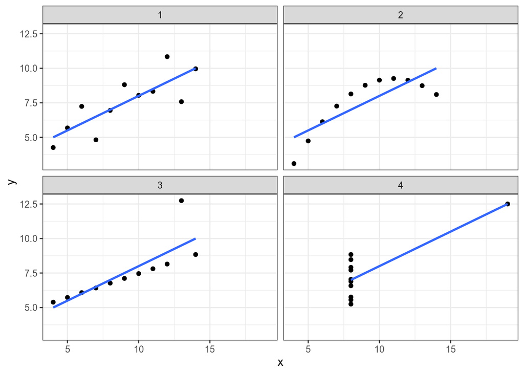

### 5.2 Datasaurus

In [Matejka and Fitzmaurice (2017) “Same Stats, Different Graphs”](https://www.autodeskresearch.com/sites/default/files/SameStats-DifferentGraphs.pdf) was presented the next sets of data:

```r
datasaurus <- read_tsv("https://raw.githubusercontent.com/agricolamz/2019.07.29_ANDAN_tidyverse/master/data/datasaurus.tsv")
head(datasaurus)
```

```
## # A tibble: 6 x 3
##   dataset     x     y
##   <chr>   <dbl> <dbl>
## 1 dino     55.4  97.2
## 2 dino     51.5  96.0
## 3 dino     46.2  94.5
## 4 dino     42.8  91.4
## 5 dino     40.8  88.3
## 6 dino     38.7  84.9
```

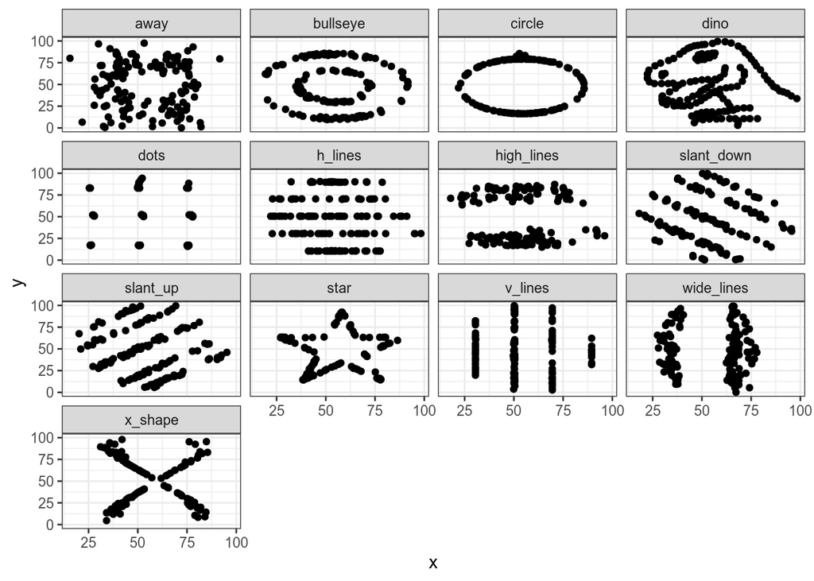

```r
datasaurus %>%
  group_by(dataset) %>%
  summarise(mean_X = mean(x),
            mean_Y = mean(y),
            sd_X = sd(x),
            sd_Y = sd(y),
            cor = cor(x, y),
            n_obs = n()) %>%
  select(-dataset) %>%
  round(., 1)
```

```
## # A tibble: 13 x 6
##    mean_X mean_Y  sd_X  sd_Y   cor n_obs
##     <dbl>  <dbl> <dbl> <dbl> <dbl> <dbl>
##  1   54.3   47.8  16.8  26.9  -0.1   142
##  2   54.3   47.8  16.8  26.9  -0.1   142
##  3   54.3   47.8  16.8  26.9  -0.1   142
##  4   54.3   47.8  16.8  26.9  -0.1   142
##  5   54.3   47.8  16.8  26.9  -0.1   142
##  6   54.3   47.8  16.8  26.9  -0.1   142
##  7   54.3   47.8  16.8  26.9  -0.1   142
##  8   54.3   47.8  16.8  26.9  -0.1   142
##  9   54.3   47.8  16.8  26.9  -0.1   142
## 10   54.3   47.8  16.8  26.9  -0.1   142
## 11   54.3   47.8  16.8  26.9  -0.1   142
## 12   54.3   47.8  16.8  26.9  -0.1   142
## 13   54.3   47.8  16.8  26.9  -0.1   142
```

### 6.1 Scaterplot

- ggplot2

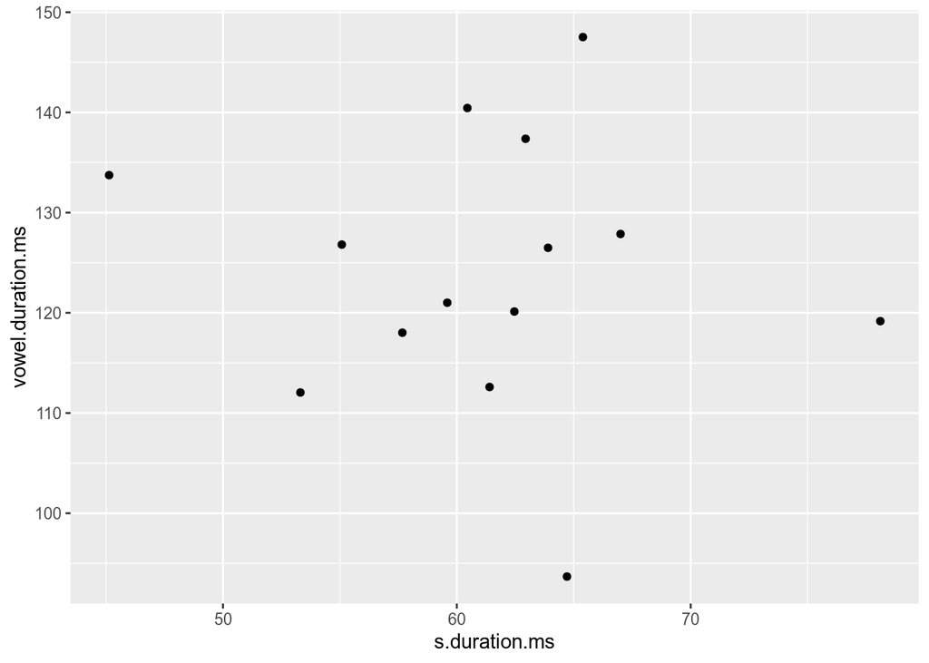

```r
ggplot(data = homo, aes(s.duration.ms, vowel.duration.ms)) +
  geom_point()
```

- dplyr, ggplot2

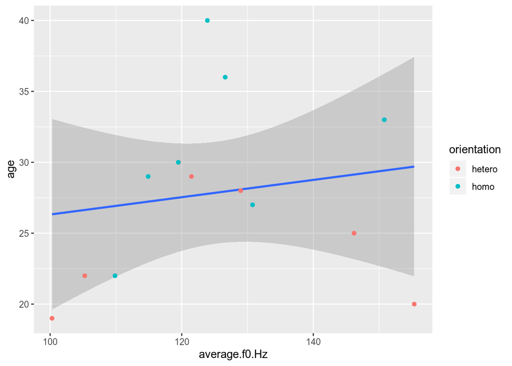

```r
homo %>%
  ggplot(aes(average.f0.Hz, age))+
  geom_smooth(method = "lm")+
  geom_point(aes(color = orientation))
```

### 6.1.1 Scaterplot: color

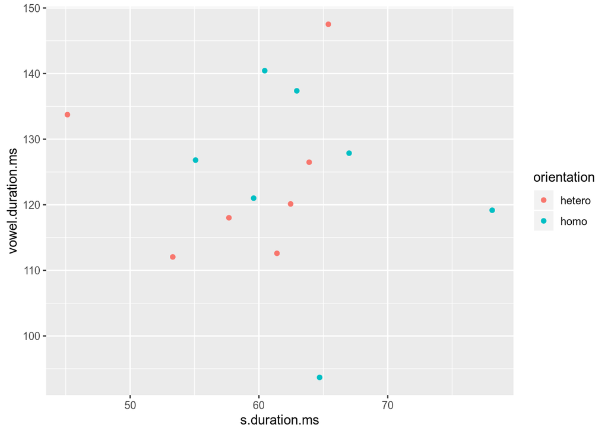

```r
homo %>%
  ggplot(aes(s.duration.ms, vowel.duration.ms,
             color = orientation)) +
  geom_point()
```

### 6.1.2 Scaterplot: shape

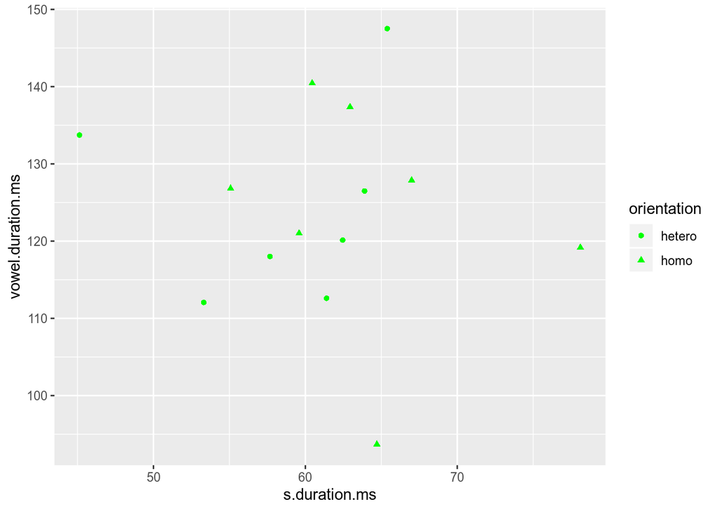

```r
homo %>%
  ggplot(aes(s.duration.ms, vowel.duration.ms,
             shape = orientation)) +
  geom_point(color = "green")
```

### 6.1.3 Scaterplot: size

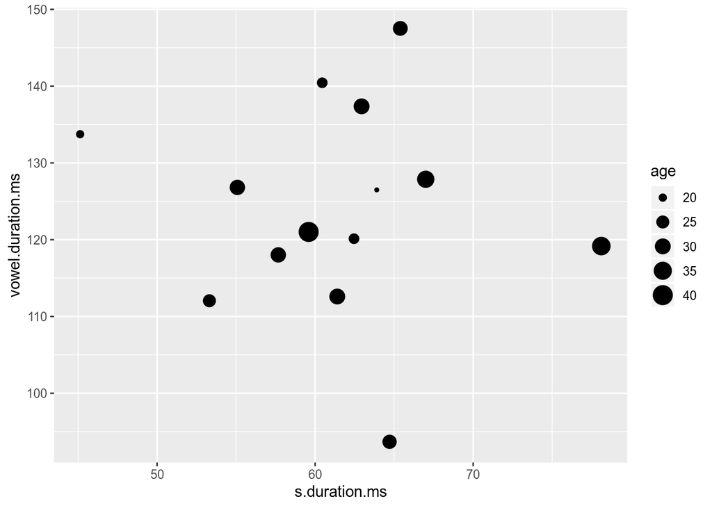

```r
homo %>%
  ggplot(aes(s.duration.ms, vowel.duration.ms,
             size = age)) +
  geom_point()
```

### 6.1.4 Scaterplot: text

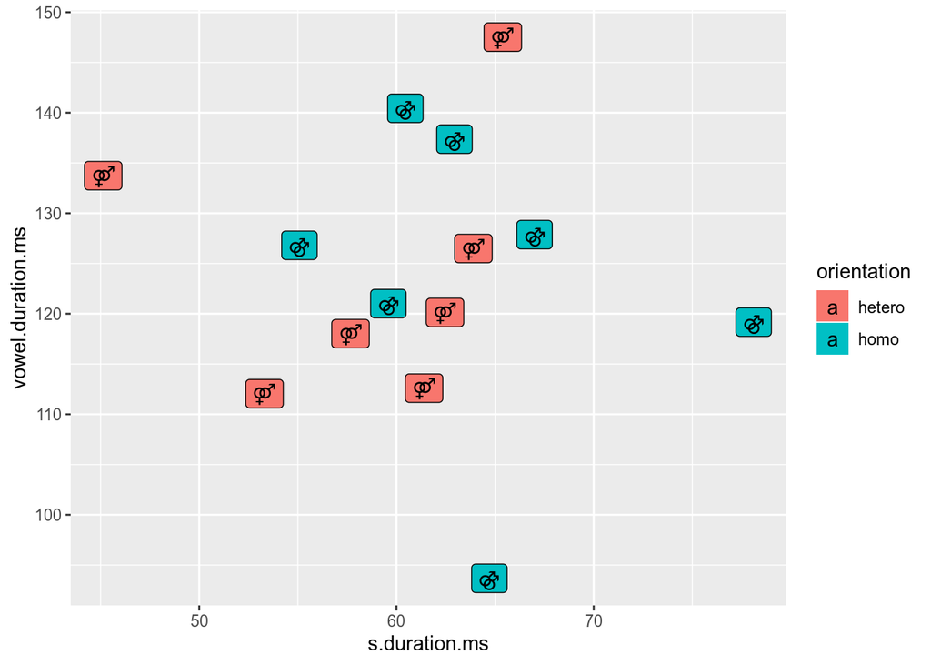

```r
homo %>%
  mutate(label = ifelse(orientation == "homo","⚣", "⚤")) %>%
  ggplot(aes(s.duration.ms, vowel.duration.ms, label = label, fill = orientation)) +
  geom_label()
```

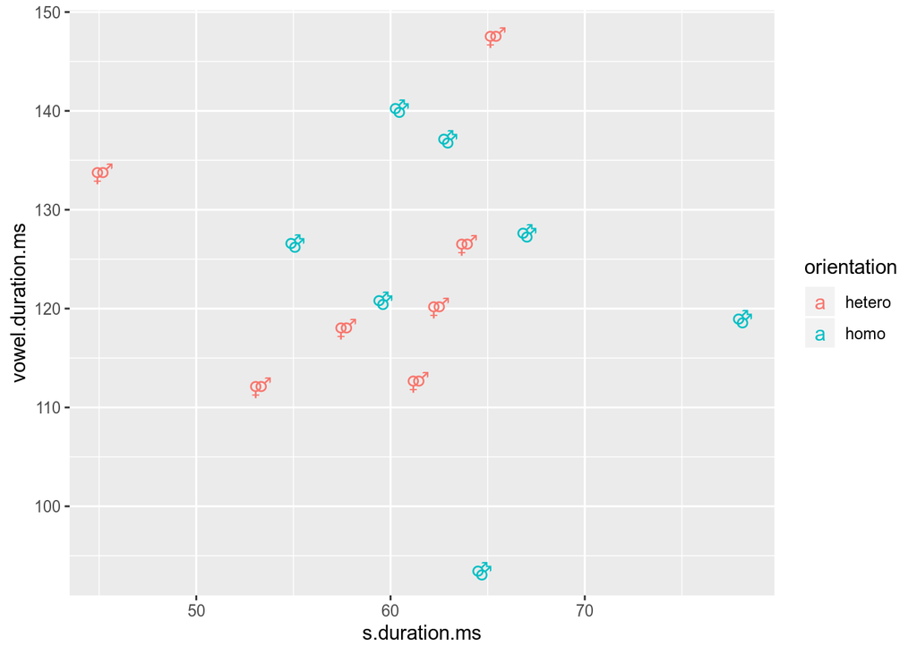

```r
homo %>%
  mutate(label = ifelse(orientation == "homo","⚣", "⚤")) %>%
  ggplot(aes(s.duration.ms, vowel.duration.ms, label = label, color = orientation)) +
  geom_text()
```

### 6.1.5 Scaterplot: title

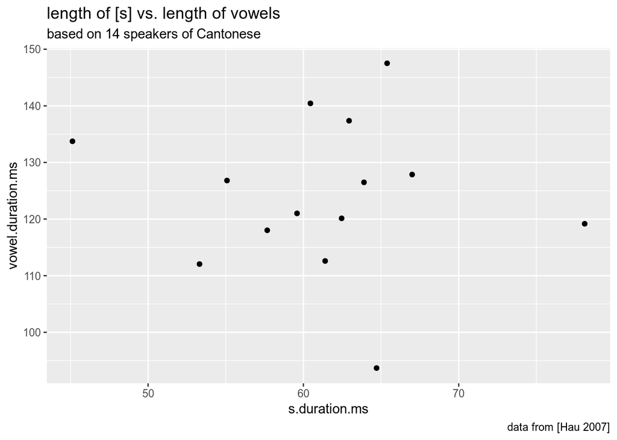

```r
homo %>%
  ggplot(aes(s.duration.ms, vowel.duration.ms)) +
  geom_point()+
  labs(title = "length of [s] vs. length of vowels",
       subtitle = "based on 14 speakers of Cantonese",
       caption = "data from [Hau 2007]")
```

### 6.1.6 Scaterplot: axis

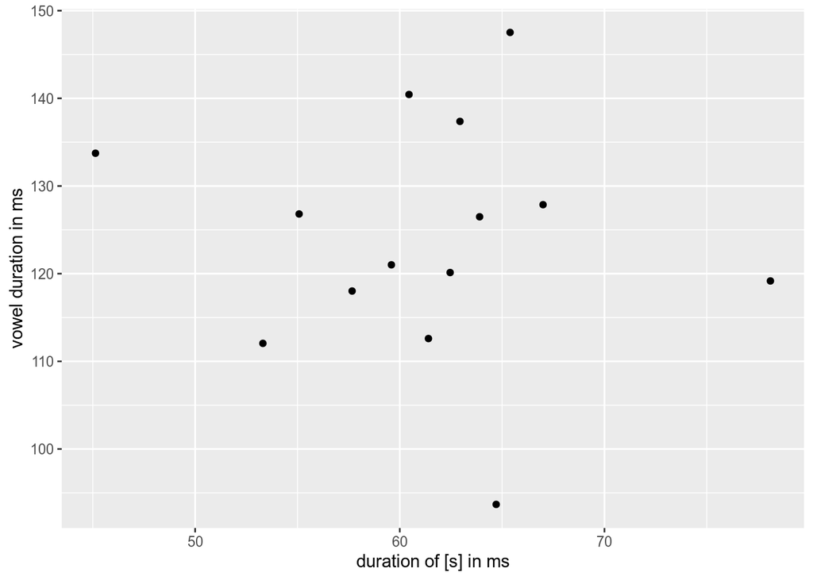

```r
homo %>%
  ggplot(aes(s.duration.ms, vowel.duration.ms)) +
  geom_point()+
  xlab("duration of [s] in ms")+
  ylab("vowel duration in ms")
```

### 6.1.7 Log scales

[figure not shown]

Lets use the frequency dictionary for Russian

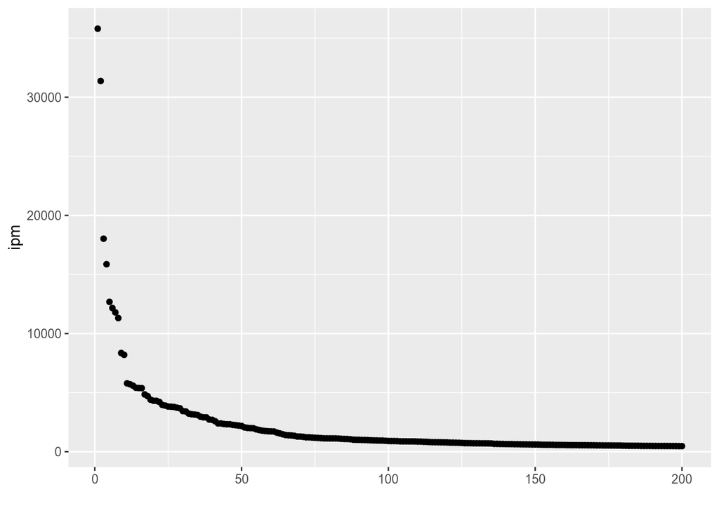

```r
freq <- read_tsv("https://raw.githubusercontent.com/agricolamz/r_on_line_course_data/master/freqrnc2011.csv")
freq %>%
  arrange(desc(`Freq(ipm)`)) %>%
  slice(1:200) %>%
  mutate(rank = 1:200) %>%
  ggplot(aes(rank, `Freq(ipm)`)) +
  geom_point() +
  xlab("") +
  ylab("ipm")
```

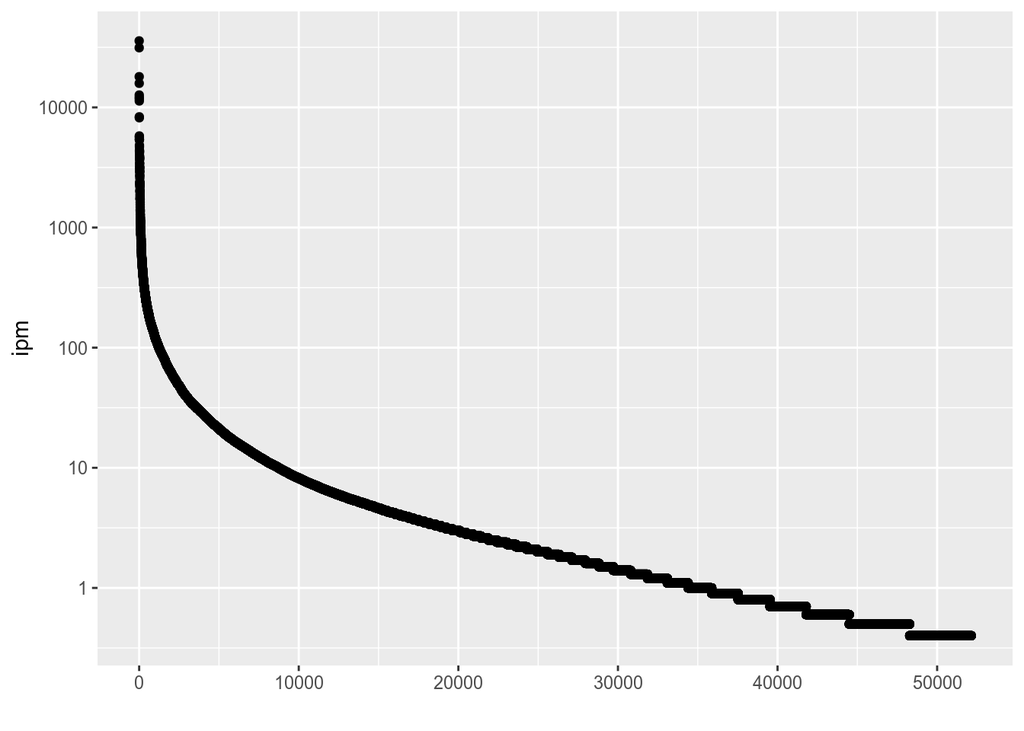

```r
freq %>%
  arrange(desc(`Freq(ipm)`)) %>%
  mutate(rank = 1:nrow(freq)) %>%
  ggplot(aes(rank, `Freq(ipm)`))+
  geom_point()+
  xlab("")+
  ylab("ipm")+
  scale_y_log10()
```

### 6.1.8 Scaterplot: rug

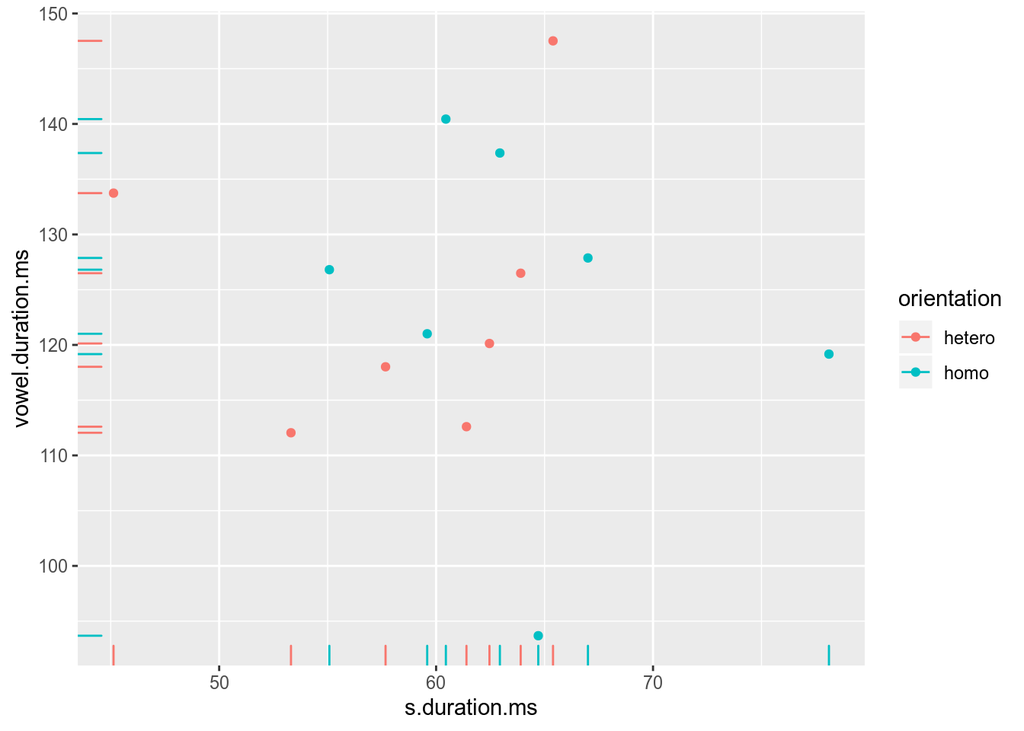

```r
homo %>%
  ggplot(aes(s.duration.ms, vowel.duration.ms, color = orientation)) +
  geom_point() +
  geom_rug()
```

### 6.1.9 Scaterplot: lines

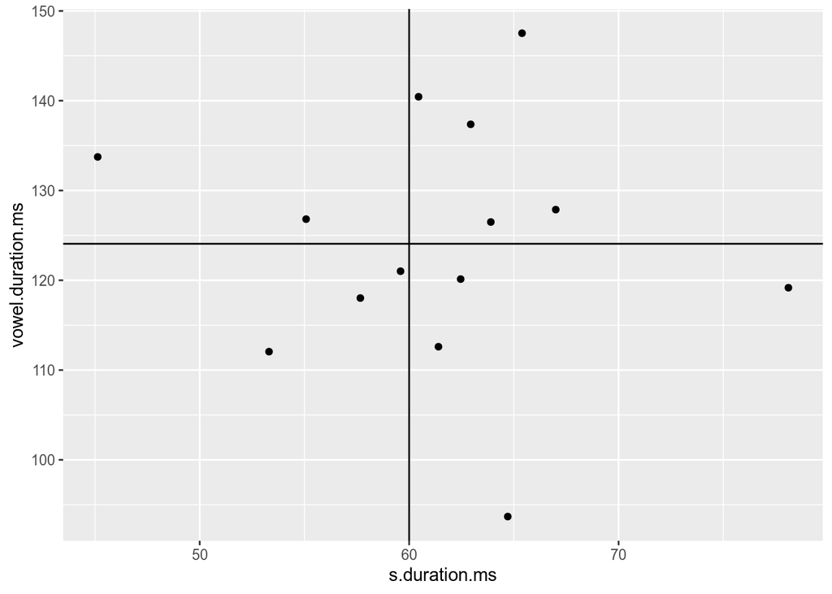

```r
homo %>%
  ggplot(aes(s.duration.ms, vowel.duration.ms)) +
  geom_point() +
  geom_hline(yintercept = mean(homo$vowel.duration.ms))+
  geom_vline(xintercept = 60)
```

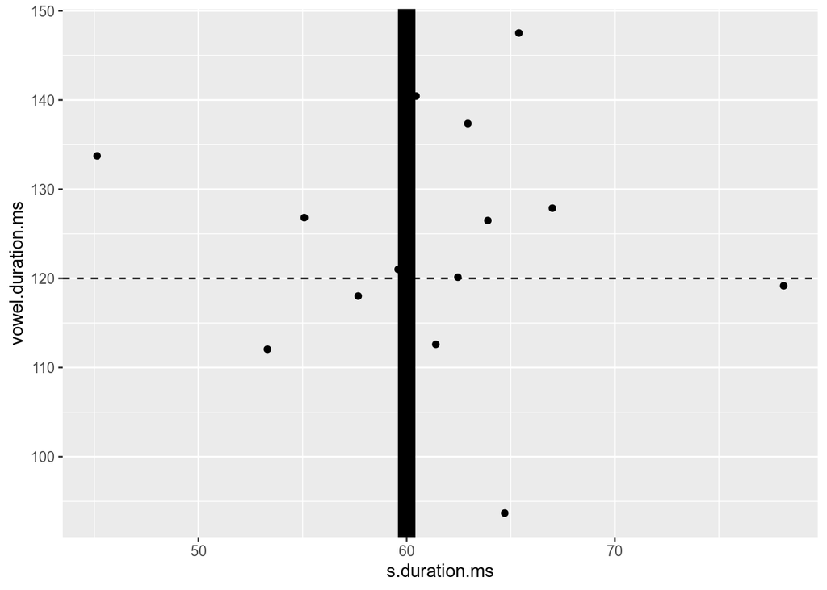

```r
homo %>%
  ggplot(aes(s.duration.ms, vowel.duration.ms)) +
  geom_point() +
  geom_hline(yintercept = 120, linetype = 2)+
  geom_vline(xintercept = 60, size = 5)
```

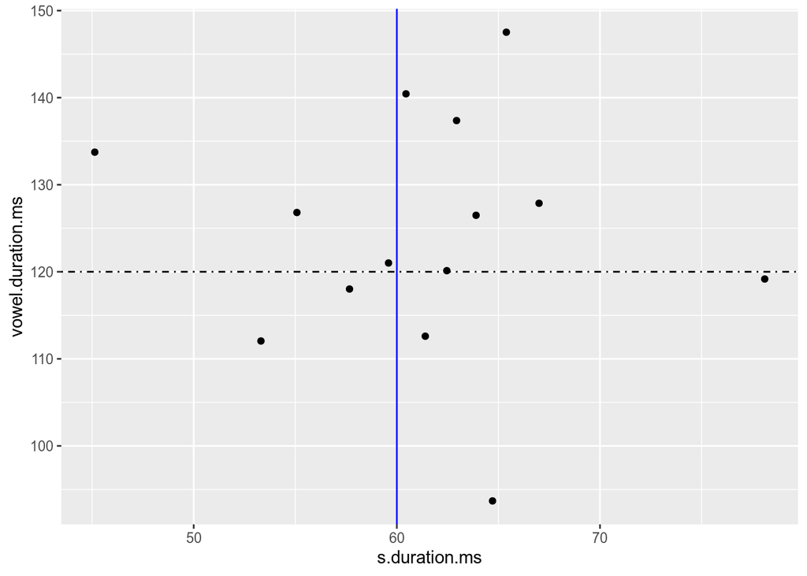

```r
homo %>%
  ggplot(aes(s.duration.ms, vowel.duration.ms)) +
  geom_point() +
  geom_hline(yintercept = 120, linetype = 4)+
  geom_vline(xintercept = 60, color = "blue")
```

### 6.1.10 Scaterplot: annotate

Функция `annotate` добавляет `geom` к графику.

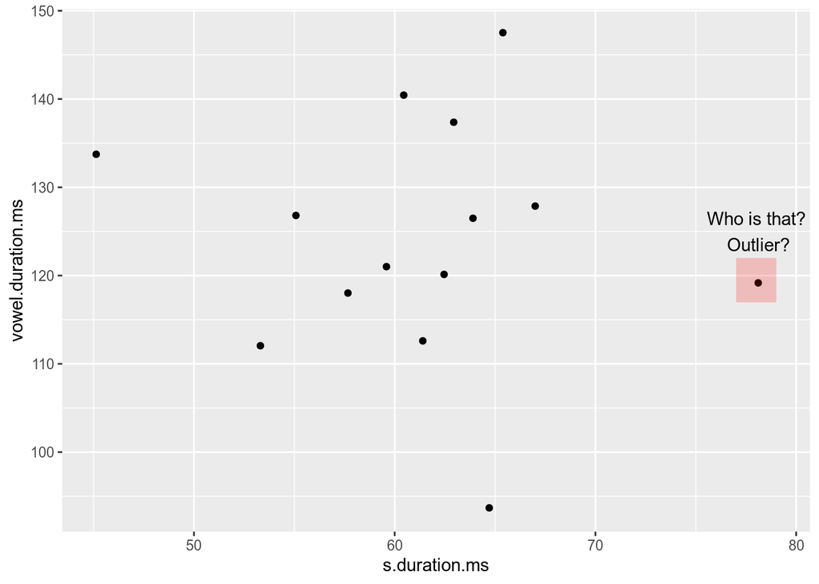

```r
homo %>%
  ggplot(aes(s.duration.ms, vowel.duration.ms)) +
  geom_point()+
  annotate(geom = "rect", xmin = 77, xmax = 79,
           ymin = 117, ymax = 122, fill = "red", alpha = 0.2) +
  annotate(geom = "text", x = 78, y = 125,
           label = "Who is that?\n Outlier?")
```

### 6.2.1 Barplots: basics

There are two possible situations:

- not aggregate data

```r
head(homo[, c(1, 9)])
```

```
## # A tibble: 6 x 2
##   speaker orientation
##   <chr>   <chr>
## 1 A       hetero
## 2 B       hetero
## 3 C       homo
## 4 D       homo
## 5 E       homo
## 6 F       homo
```

- aggregate data

```r
head(homo[, c(1, 10)])
```

```
## # A tibble: 6 x 2
##   speaker   age
##   <chr>   <dbl>
## 1 A          30
## 2 B          19
## 3 C          29
## 4 D          36
## 5 E          27
## 6 F          33
```

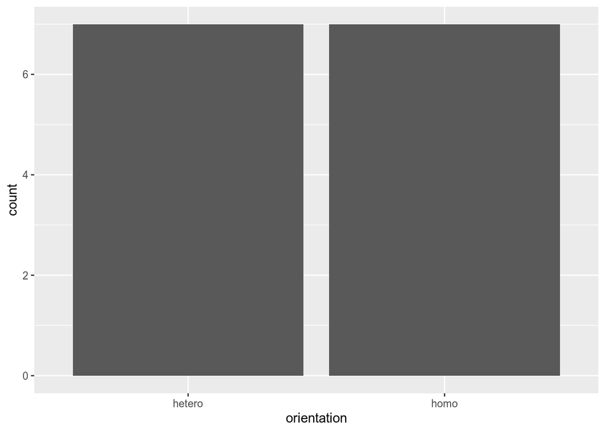

```r
homo %>%
  ggplot(aes(orientation)) +
  geom_bar()
```

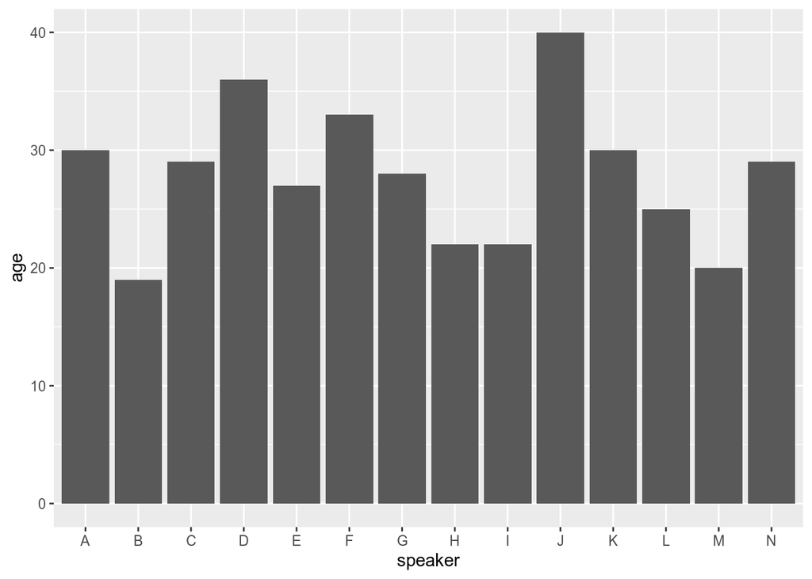

```r
homo %>%
  ggplot(aes(speaker, age)) +
  geom_col()
```

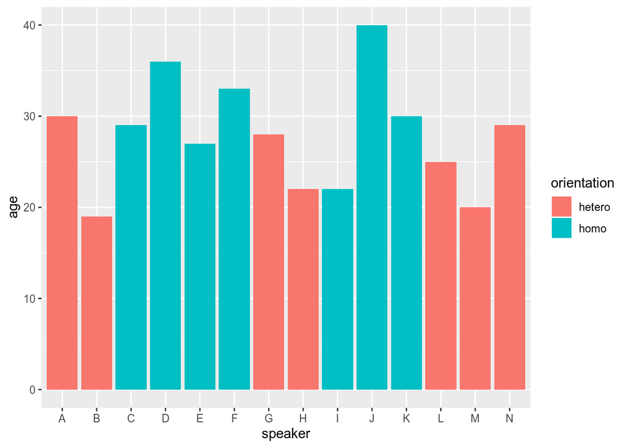

```r
homo %>%
  ggplot(aes(speaker, age, fill = orientation)) +
  geom_col()
```

### 6.3.1 Boxplots: basics, points, jitter

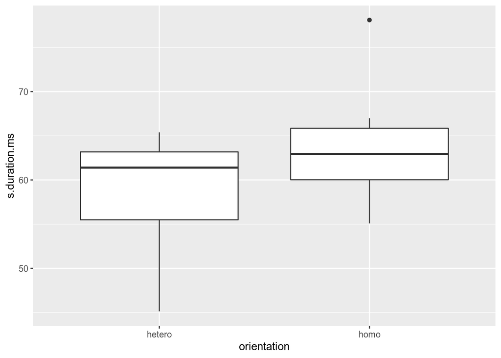

```r
homo %>%
  ggplot(aes(orientation, s.duration.ms)) +
  geom_boxplot()
```

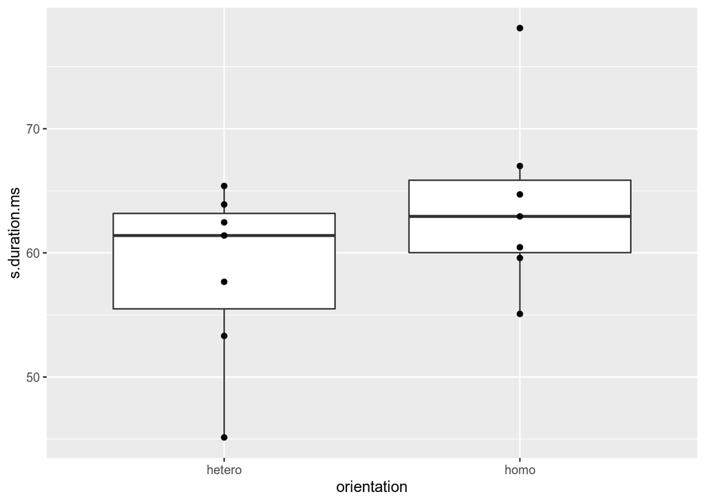

```r
homo %>%
  ggplot(aes(orientation, s.duration.ms)) +
  geom_boxplot()+
  geom_point()
```

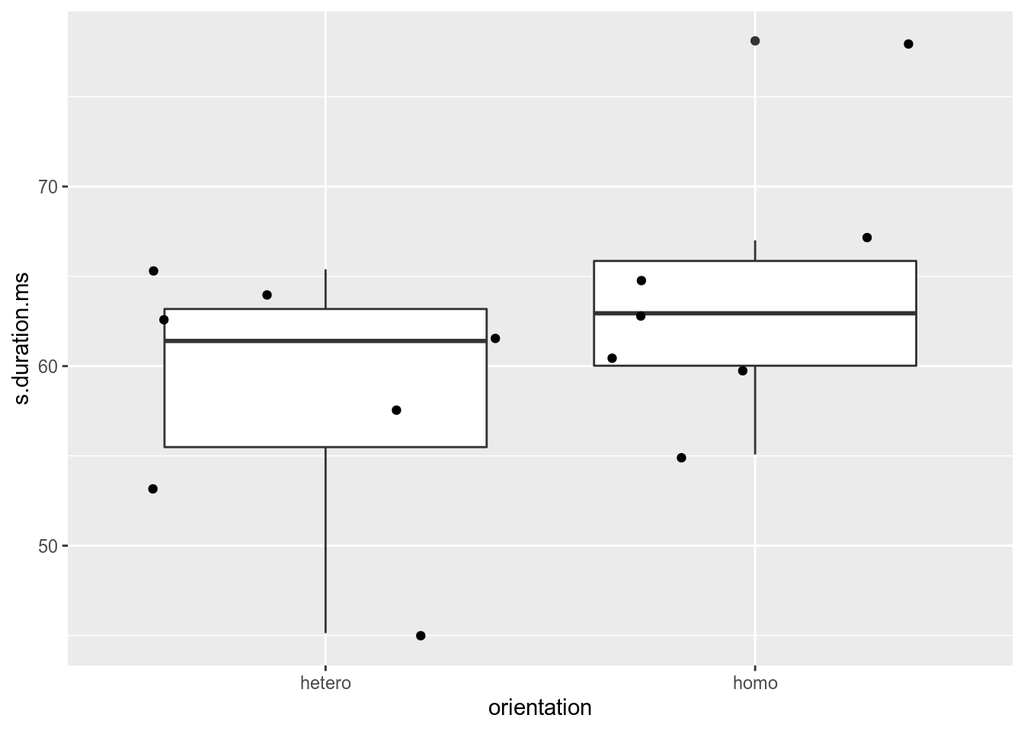

```r
homo %>%
  ggplot(aes(orientation, s.duration.ms)) +
  geom_boxplot() +
  geom_jitter(width = 0.5)
```

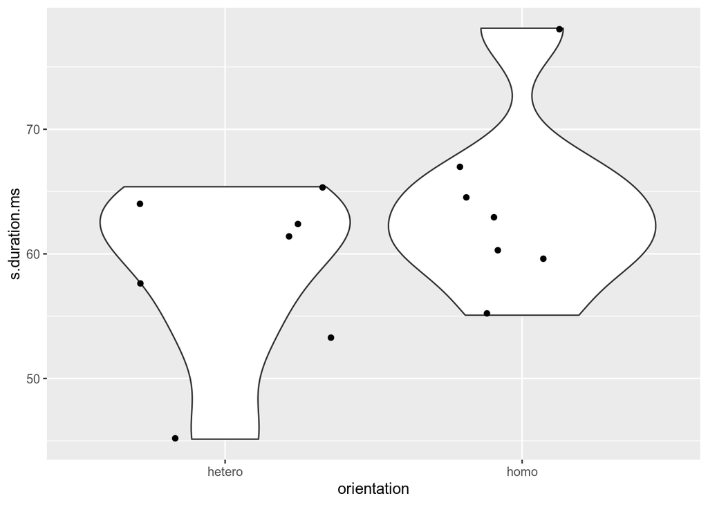

```r
homo %>%
  ggplot(aes(orientation, s.duration.ms)) +
  geom_violin() +
  geom_jitter()
```

### 6. Preliminary summary: two variables

- scaterplot: two quantitative varibles
- barplot: nominal varible and one number
- boxplot: nominal varible and quantitative varibles
- jittered points or sized points: two nominal varibles

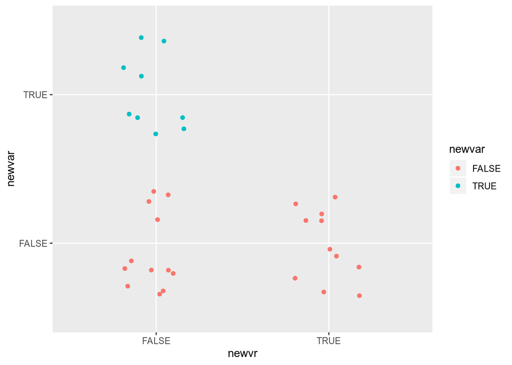

```r
mtcars %>%
  mutate(newvar = mpg > 22,
         newvr = mpg < 17) %>%
  ggplot(aes(newvr, newvar, color = newvar))+
  geom_jitter(width = 0.2)
```

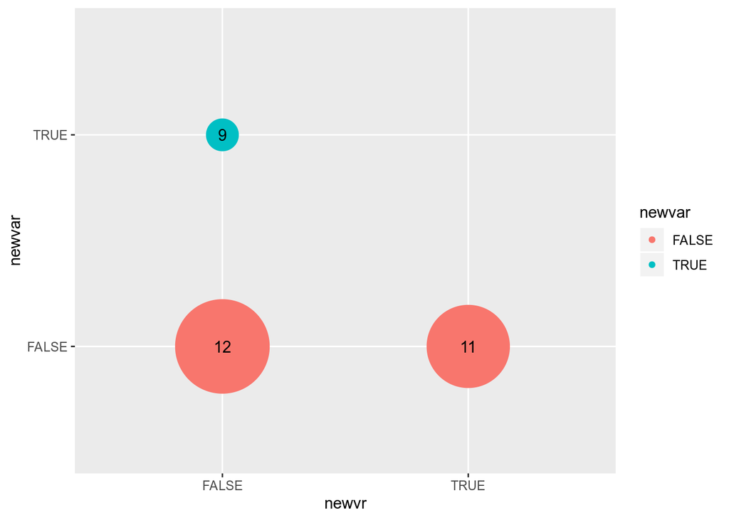

```r
mtcars %>%
  mutate(newvar = mpg > 22,
         newvr = mpg < 17) %>%
  group_by(newvar, newvr) %>%
  summarise(number = n()) %>%
  ggplot(aes(newvr, newvar, label = number))+
  geom_point(aes(size = number, color = newvar))+
  geom_text()+
  scale_size(range = c(10, 30))+
  guides(size = F)
```

### 6.4.1 Histogram: basics

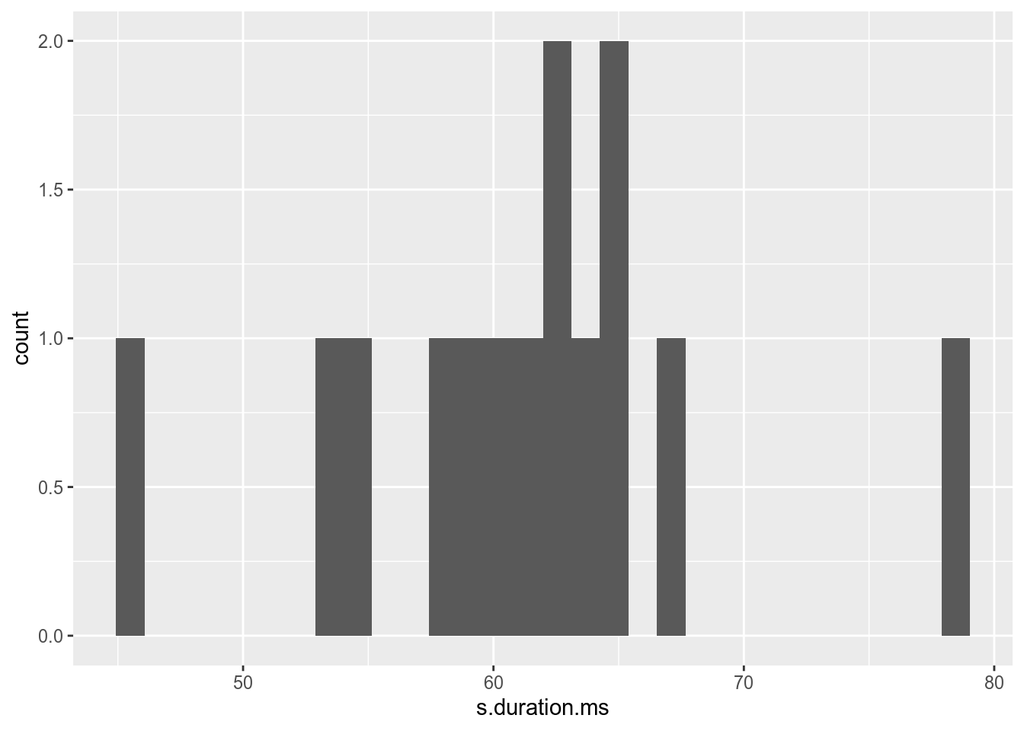

```r
homo %>%
  ggplot(aes(s.duration.ms)) +
  geom_histogram()
```

How many histogram bins do we need?

- [Sturgers 1926] `nclass.Sturges(homo$s.duration.ms)`
- [Scott 1979] `nclass.scott(homo$s.duration.ms)`
- [Freedman, Diaconis 1981] `nclass.FD(homo$s.duration.ms)`

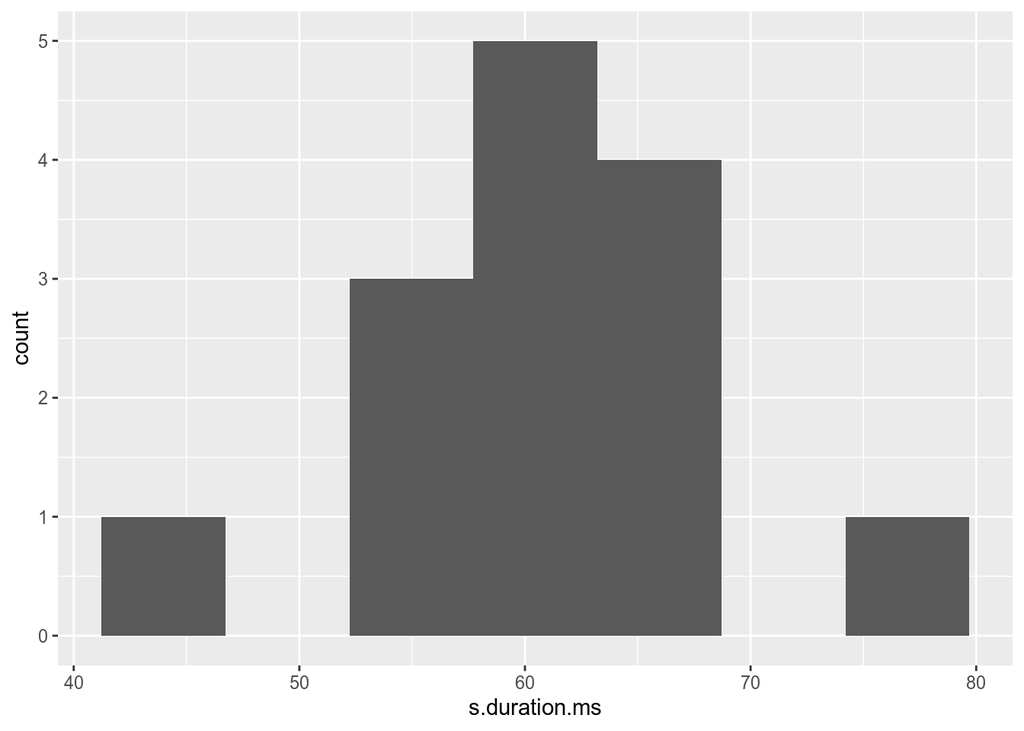

```r
homo %>%
  ggplot(aes(s.duration.ms)) +
  geom_histogram(bins = nclass.FD(homo$s.duration.ms))
```

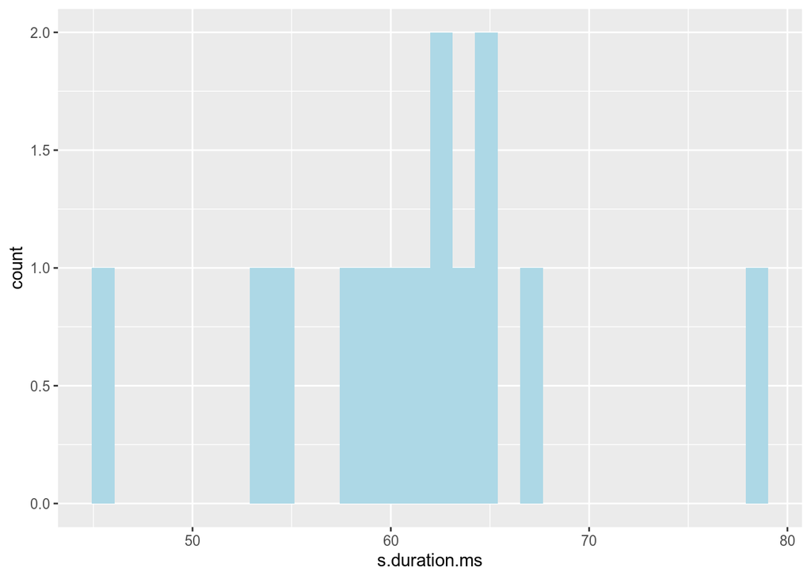

```r
homo %>%
  ggplot(aes(s.duration.ms)) +
  geom_histogram(fill = "lightblue")
```